# Factory Machine Status

Name: Ng Yu Hang  
Admin Number: [student-id]  
Class: DAAA/FT/1B/07

# Project Objective

Create a supervised classification model to predict Factory Machine Status

# Background

This is a dataset collected from a manufacturing factory. The dataset contains various information on different machines. From the perspective of quality control, the factory wants to build a machine learning model to predict whether the machine is working properly or faulty

# Phases

1. Importing data (read csv file)
2. Data Exploration, Data Preparation and Feature Engineering
3. Setting up the models and model improvement tunings
4. Training and Evaluating the improved models
5. Creating a baseline model for performance comparison
6. Determine Model Performance
7. Reliability check
8. Determining the best model for this task

# Importing necessary libraries

```python
import pandas as pd
import matplotlib.pyplot as plt
import seaborn as sns
import numpy as np
import warnings
from sklearn.dummy import DummyClassifier
from sklearn.model_selection import train_test_split, StratifiedKFold, GridSearchCV, cross_val_score
from sklearn.preprocessing import StandardScaler, OneHotEncoder
from sklearn.pipeline import Pipeline
from sklearn.compose import ColumnTransformer
from sklearn.linear_model import LogisticRegression
from sklearn.svm import SVC
from sklearn.ensemble import RandomForestClassifier, GradientBoostingClassifier, AdaBoostClassifier
from sklearn.neighbors import KNeighborsClassifier
from sklearn.tree import DecisionTreeClassifier
from sklearn.metrics import classification_report, confusion_matrix, accuracy_score, roc_curve, auc, f1_score, roc_auc_score
from sklearn.impute import SimpleImputer

warnings.filterwarnings("ignore", category=FutureWarning, module="pandas")
warnings.filterwarnings("ignore", category=FutureWarning, module="matplotlib")
warnings.filterwarnings("ignore", category=FutureWarning, module="seaborn")
warnings.filterwarnings("ignore", category=FutureWarning, module="numpy")
warnings.filterwarnings("ignore", category=FutureWarning, module="sklearn")
```

Here, we import all the required module libraries, as well as using `warnings library` to clear any warnings to make the report much more clean and neat.

# Phase 1: Importing data (read csv file)

## Importing the csv file

```python
data = pd.read_csv('factory_data.csv')
data.head(15)
```

|  | Unique ID | Product ID | Quality | Ambient T (C) | Process T (C) | Rotation Speed (rpm) | Torque (Nm) | Tool Wear (min) | Machine Status |
| --- | --- | --- | --- | --- | --- | --- | --- | --- | --- |
| 0 | 1 | K12965 | M | 24.95 | 35.45 | 1551.0 | 42.8 | 0 | 0 |
| 1 | 2 | Z62710 | L | 25.05 | 35.55 | 1408.0 | 46.3 | 3 | 0 |
| 2 | 3 | T20224 | L | 24.95 | 35.35 | 1498.0 | 49.4 | 5 | 0 |
| 3 | 4 | Z33024 | L | 25.05 | 35.45 | 1433.0 | 39.5 | 7 | 0 |
| 4 | 5 | Z52839 | L | 25.05 | 35.55 | 1408.0 | 40.0 | 9 | 0 |
| 5 | 6 | K53611 | M | 24.95 | 35.45 | 1425.0 | 41.9 | 11 | 0 |
| 6 | 7 | K40563 | L | 24.95 | NaN | NaN | 42.4 | 14 | 0 |
| 7 | 8 | T39301 | L | 24.95 | 35.45 | 1527.0 | 40.2 | 16 | 0 |
| 8 | 9 | S84663 | M | 25.15 | 35.55 | 1667.0 | 28.6 | 18 | 0 |
| 9 | 10 | Z56249 | M | 25.35 | 35.85 | 1741.0 | 28.0 | 21 | 0 |
| 10 | 11 | K30974 | NaN | 25.25 | 35.75 | 1782.0 | 23.9 | 24 | 0 |
| 11 | 12 | Z17920 | H | 25.45 | 35.95 | 1423.0 | 44.3 | 29 | 0 |
| 12 | 13 | T37320 | M | 25.45 | 35.95 | 1339.0 | 51.1 | 34 | 0 |
| 13 | 14 | Z85528 | M | 25.45 | 36.05 | 1742.0 | 30.0 | 37 | 0 |
| 14 | 15 | T39889 | NaN | 25.45 | 36.05 | 2035.0 | 19.6 | 40 | 0 |

Here, we import our csv file using `pd.read_csv('factory_data.csv')`, and using `data.head(15)` to show the first 15 rows of every column, just to have a general look at our dataset.

# Phase 2: Data Exploration, Data Preparation and Feature Engineering

## Describing our data content

```python
data.describe().style.background_gradient(cmap="Purples")
```

| Â | Unique ID | Ambient T (C) | Process T (C) | Rotation Speed (rpm) | Torque (Nm) | Tool Wear (min) | Machine Status |
| --- | --- | --- | --- | --- | --- | --- | --- |
| count | 20000.000000 | 20000.000000 | 19600.000000 | 18812.000000 | 20000.000000 | 20000.000000 | 20000.000000 |
| mean | 10000.500000 | 26.904930 | 36.904291 | 1538.795397 | 39.986910 | 107.951000 | 0.033900 |
| std | 5773.647028 | 2.000834 | 1.483647 | 178.674963 | 9.968684 | 63.652555 | 0.180976 |
| min | 1.000000 | 22.150000 | 32.550000 | 1168.000000 | 3.800000 | 0.000000 | 0.000000 |
| 25% | 5000.750000 | 25.250000 | 35.750000 | 1423.000000 | 33.200000 | 53.000000 | 0.000000 |
| 50% | 10000.500000 | 26.950000 | 36.950000 | 1503.000000 | 40.100000 | 108.000000 | 0.000000 |
| 75% | 15000.250000 | 28.450000 | 37.950000 | 1613.000000 | 46.800000 | 162.000000 | 0.000000 |
| max | 20000.000000 | 31.450000 | 40.750000 | 2886.000000 | 76.600000 | 253.000000 | 1.000000 |

The table shows that there are 20,000 rows, and 7 columns of numerical data. From the count row, we can see that there are missing numerical datas for Rotation Speed and Process T (C). However we are unsure if other non-numerical data columns have missing data, so we need data.isnull().sum() to confirm, as well as view the number of missing rows easier.

### Further check for number of missing datas

```python
data.isnull().sum()
```

```
Unique ID                  0
Product ID                 0
Quality                  991
Ambient T (C)              0
Process T (C)            400
Rotation Speed (rpm)    1188
Torque (Nm)                0
Tool Wear (min)            0
Machine Status             0
dtype: int64
```

From this, we could see there are 991 missing values for Quality, 400 missing values for Process T (C) and 1188 missing values for Rotation Speed (rpm). Our models need complete datas to train, hence we can either impute using imputing methods like SimpleImputer() or we can drop (remove) the rows with missing data, as we have enough data to train a reliable model with.

### Visualization of % of missing datas:

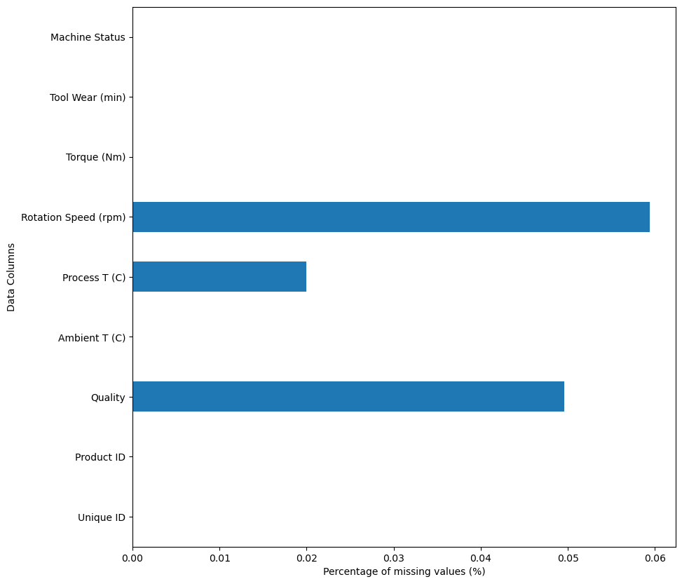

```python
data.isna().mean().plot.barh(figsize=(10,10))
plt.ylabel("Data Columns")
plt.xlabel("Percentage of missing values (%)")
plt.show()
```

## Setting up Data for both dropna() and SimpleImputer()

```python
imputed_data = data.copy()
dropna_data = data.dropna()
print("Number of rows after dropping missing values:", dropna_data.shape[0])
```

```
Number of rows after dropping missing values: 17529
```

This tells us that we now have `17,529` rows of data with completely filled original data.  
For the imputed_date, we copied the original data instead of tampering with the original data, so that we can refer back to it afterwards if needed for any referencing.  
There are pros and cons of using both either `dropna()` method or `SimpleImputer() method`. With the main ones as follows:

`dropna() pros` is that it removes the rows with missing columns, so there is no need to guess fake data, hence every data left in the dataset is completely true.  
`dropna() cons` is that because it is removing rows of data, we would end up with lesser data to work with. Which can be a problem for smaller datasets, or if there is a LARGE amount of missing data.

`SimpleImputer() pros` is that we get to retain the amount of data in our dataset, with datas that are as close to being correct as possible using the other available datas.  
`SimpleImputer() cons` is that while we get to keep the amount of data, the accuracy of the model might suffer because of the fake imputed data.

## Selecting data features and target

### Selecting the target column

```python
target_column = 'Machine Status'

X_dropna = dropna_data.drop(target_column, axis=1)
y_dropna = dropna_data[target_column]

X_imputed = imputed_data.drop(target_column, axis=1)
y_imputed = imputed_data[target_column]
```

I create a variable called target_column so we can change the target column conveniently while not having to change the rest of the code that uses the target column code.  
I then assign y to the target column so that y contains the target data.

I drop the target column from the original data so that the target column does not get used for to train the model, preventing a data leakage, making sure the model learns it using the patterns in the features, rather than being able to refer to the answer directly.

### Pick feature data and identify the columns with numerical and categorical data

```python
numerical_columns = ['Ambient T (C)', 'Process T (C)', 'Rotation Speed (rpm)', 'Torque (Nm)', 'Tool Wear (min)']
categorical_columns = ['Quality']
```

I first picked out the features I want to include and assign them to numerical_columns and categorical_columns according to whether they contain numerical or categorical data. The excluded columns (Unique ID and Product ID) are columns that contain irrelevant data, hence we do not need to include them as we will not be using them to train the model.

### Analysis

#### Correlation Analysis

Using a correlation matrix, it helps us analyze the strength of the relationship between two or more features.

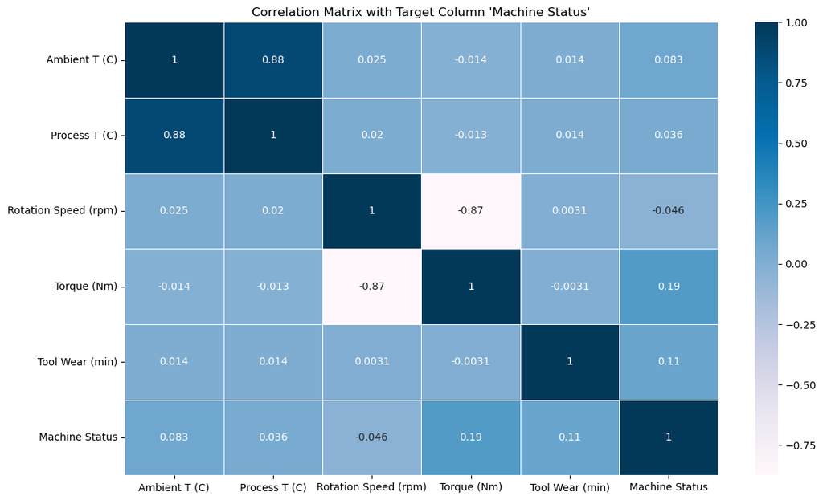

```python
plt.figure(figsize=(13, 8))
sns.heatmap(data[numerical_columns].join(data[[target_column]]).corr(), annot=True, cmap="PuBu", linewidths=0.5)
plt.title("Correlation Matrix with Target Column 'Machine Status'")
plt.show()
```

From this, we could see that the `Torque (Nm)` has the highest correlation to the target variable

#### Univariate Analysis

##### Histograms

We can explore the distribution of each of the variables using histograms to visualize how frequent each range of values occurs.

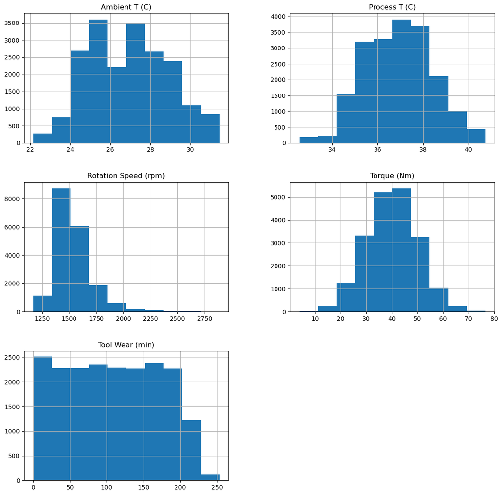

```python
data[numerical_columns].hist(figsize=(14,14))
plt.show()
```

##### Box Plots

Using a box plot, we can visualize each numerical variable's distribution and their spread, as well as their outliers.

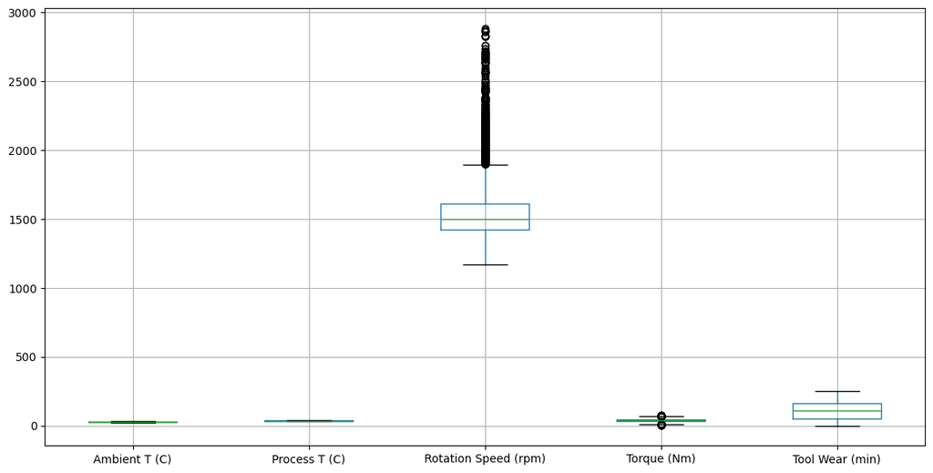

```python
data[numerical_columns].boxplot(figsize=(14,7))
plt.show()
```

Notice that Rotation Speed has a lot of outliers. Even though they are outliers, they are useful for models to learn what are the outcomes of the target data in more extreme conditions (the outlier conditions). This can help with greater reliability of the models.

### Checking for class imbalance in target data

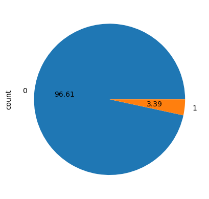

```python
data[target_column].value_counts().plot.pie(autopct="%.2f")
```

From this pie chart, we can see that there is a massive class imbalance in the target column. There are 96.61% instances of "0" and only 3.39% instance of "1" appearing.  
Hence, what we could expect is a very large difference in accuracy between predicting the two results.

## Feature Engineering: Preprocessing our data

### Applying the preprocessors to both dropna() data and SimpleImputer() datas

```python
# Preprocessor for dropna data
dropna_preprocessor = ColumnTransformer([
    ('num', StandardScaler(), numerical_columns),
    ('cat', OneHotEncoder(drop='first'), categorical_columns)
])

# Preprocessor for imputed data with SimpleImputer
imputer_preprocessor = ColumnTransformer([
    ('num', Pipeline([('imputer', SimpleImputer(strategy='mean')), ('scaler', StandardScaler())]), numerical_columns),
    ('cat', Pipeline([('imputer', SimpleImputer(strategy='most_frequent')), ('encoder', OneHotEncoder(drop='first'))]), categorical_columns)
])
```

Here, i assign column transformers (StandardScaler and OneHotEncoder) to both `dropna data` and `imputed data`.

`StandardScaler` scales numerical features to have a mean of 0, and a standard deviation of 1. This helps with improving many models' performance.

`OneHotEncoder` is used on categorical data to create numerical data by creating binary columns.

(drop='first') is used for dropping the first column in the OneHotEncoder binary column to create redundancy (for instance, if there are 3 categories, if 2 columns of the categories are 0, it just means its the 3rd category)

## Train_test_split for both dropna() and SimpleImputer() data

I use train_test_split to split the data into training and testing data in the ratio of the value in test_size. I used 0.3, which means it would split the data to have 70% data for training, 30% data for testing.

```python
X_train_dropna, X_test_dropna, y_train_dropna, y_test_dropna = train_test_split(X_dropna, y_dropna, test_size=0.3, stratify=y_dropna)
X_train_imputed, X_test_imputed, y_train_imputed, y_test_imputed = train_test_split(X_imputed, y_imputed, test_size=0.3, stratify=y_imputed)
```

I used two different train_test_splits so that each data wouldn't affect each other after imputation or dropping, so I can have a fair comparison between their performance and reliability.

# Phase 3: Setting up the models and model improvement tunings

### Setting up KFolds

I am using Stratified K-Fold instead of the normal KFold because as seen in above analysis, there is a massive class imbalance. Stratified K-Fold is well-suited for classification tasks as it maintains the proportion of each class in each fold.  
This results in better model consistency as well as lower biasness which produces a more reliable model.

```python
stratified_kf = StratifiedKFold(n_splits=5, shuffle=True, random_state=42)
```

### Defining parameter grids for models

Parameter Grids are used for controlling the model's complexity, regularization and behaviour. They define the range of hyperparameters that will be tested during hyperparameter tuning. They are then used with GridSearchCV to find the best combination of parameters and the best config for the model.

```python
param_grids = {
    'Logistic Regression': {
        'logreg__C': [0.0001, 0.001, 0.01, 0.05],
        'logreg__penalty': ['l2'],
        'logreg__solver': ['liblinear'],
        'logreg__class_weight': ['balanced']
    },
    'SVC': {
        'svc__C': [0.001, 0.005, 0.01],
        'svc__kernel': ['linear'],
        'svc__gamma': ['scale'],
        'svc__class_weight': ['balanced']
    },
    'Random Forest': {
        'forest__n_estimators': [50, 100, 150],
        'forest__max_depth': [5, 10, 15],
        'forest__min_samples_split': [40, 50, 60],
        'forest__class_weight': ['balanced']
    },
    'KNN': {
        'knn__n_neighbors': [3, 5, 7],
        'knn__weights': ['uniform']
    },
    'Decision Tree': {
        'dt__max_depth': [5, 10, 15],
        'dt__min_samples_split': [40, 50, 60],
        'dt__class_weight': ['balanced']
    },
    'Gradient Boosting': {
        'gb__n_estimators': [50, 100, 150],
        'gb__learning_rate': [0.01, 0.02, 0.03],
        'gb__max_depth': [3, 4, 5]
    },
    'AdaBoost': {
        'ab__n_estimators': [50, 100, 150],
        'ab__learning_rate': [0.01, 0.02, 0.03]
    }
}
```

As the hyperparameters I have used show, I have leaned more towards underfitting the models so it's less bias towards the majority data. Since this is an imbalanced dataset, it is much safer to underfit.  
This is because, even though underfitting can cause a drop in performance, it does not overfit to generalize the majority data, it instead gives a more reliable result that fairly determines both the majority and minority data.

### Defining Models with pipelines for both dropna and simpleimputer data

#### This defines the models for dropna() data

```python
models_dropna = {
    'Logistic Regression': Pipeline([
        ('preprocessor', dropna_preprocessor),
        ('logreg', LogisticRegression(max_iter=500, class_weight='balanced'))
    ]),
    'SVC': Pipeline([
        ('preprocessor', dropna_preprocessor),
        ('svc', SVC(probability=True, class_weight='balanced'))
    ]),
    'Random Forest': Pipeline([
        ('preprocessor', dropna_preprocessor),
        ('forest', RandomForestClassifier())
    ]),
    'KNN': Pipeline([
        ('preprocessor', dropna_preprocessor),
        ('knn', KNeighborsClassifier())
    ]),
    'Decision Tree': Pipeline([
        ('preprocessor', dropna_preprocessor),
        ('dt', DecisionTreeClassifier())
    ]),
    'Gradient Boosting': Pipeline([
        ('preprocessor', dropna_preprocessor),
        ('gb', GradientBoostingClassifier())
    ]),
    'AdaBoost': Pipeline([
        ('preprocessor', dropna_preprocessor),
        ('ab', AdaBoostClassifier())
    ])
}
```

#### This defines the models for SimpleImputer() data

```python
models_imputed = {
    'Logistic Regression': Pipeline([
        ('preprocessor', imputer_preprocessor),
        ('logreg', LogisticRegression(max_iter=500, class_weight='balanced'))
    ]),
    'SVC': Pipeline([
        ('preprocessor', imputer_preprocessor),
        ('svc', SVC(probability=True, class_weight='balanced'))
    ]),
    'Random Forest': Pipeline([
        ('preprocessor', imputer_preprocessor),
        ('forest', RandomForestClassifier())
    ]),
    'KNN': Pipeline([
        ('preprocessor', imputer_preprocessor),
        ('knn', KNeighborsClassifier())
    ]),
    'Decision Tree': Pipeline([
        ('preprocessor', imputer_preprocessor),
        ('dt', DecisionTreeClassifier())
    ]),
    'Gradient Boosting': Pipeline([
        ('preprocessor', imputer_preprocessor),
        ('gb', GradientBoostingClassifier())
    ]),
    'AdaBoost': Pipeline([
        ('preprocessor', imputer_preprocessor),
        ('ab', AdaBoostClassifier())
    ])
}
```

Using pipeline, I can link the models to use the respective data processing methods using the previously defined preprocessors. Pipelines make the code cleaner and easier to make changes to, as well as make sure the same transformations are consistently applied to both train and test data, preventing Data Leakage.

## Testing how well the models run without the hyperparameters first

```
Model Logistic Regression prediction accuracy is 80.6%, f1-score is 86.7%, AUC score is 0.904
Model SVC prediction accuracy is 92.4%, f1-score is 94.2%, AUC score is 0.973
Model Random Forest prediction accuracy is 99.3%, f1-score is 99.2%, AUC score is 0.989
Model KNN prediction accuracy is 97.9%, f1-score is 97.7%, AUC score is 0.944
Model Decision Tree prediction accuracy is 99.1%, f1-score is 99.1%, AUC score is 0.928
Model Gradient Boosting prediction accuracy is 98.7%, f1-score is 98.6%, AUC score is 0.975
Model AdaBoost prediction accuracy is 97.4%, f1-score is 97.2%, AUC score is 0.965
```

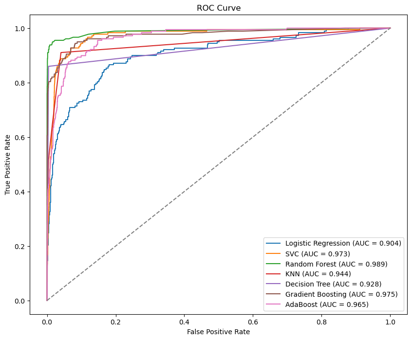

```python
plt.figure(figsize=(10, 8))

for name, model in models_dropna.items():
    model.fit(X_train_dropna, y_train_dropna)
    y_pred = model.predict(X_test_dropna)
    y_prob = model.predict_proba(X_test_dropna)[:, 1]
    accuracy = accuracy_score(y_test_dropna, y_pred)
    f1 = f1_score(y_test_dropna, y_pred, average='weighted')
    fpr, tpr, _ = roc_curve(y_test_dropna, y_prob)
    auc_score = roc_auc_score(y_test_dropna, y_prob)

    print(f'Model {name} prediction accuracy is {accuracy*100:.1f}%, f1-score is {f1*100:.1f}%, AUC score is {auc_score:.3f}')
    plt.plot(fpr, tpr, label=f'{name} (AUC = {auc_score:.3f})')

plt.plot([0, 1], [0, 1], linestyle='--', color='grey')
plt.xlabel('False Positive Rate')
plt.ylabel('True Positive Rate')
plt.title('ROC Curve')
plt.legend(loc='lower right')
plt.show()
```

We can also see that models like KNN and Decision Tree seem to not be doing well as they have a very sharp turn.

### Feature Importance

```
Model: Random Forest
```

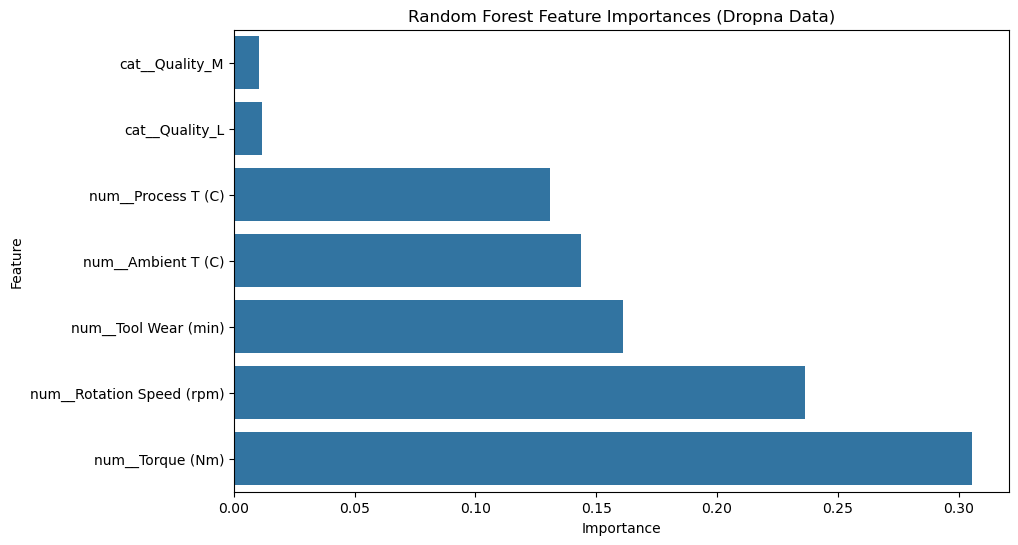

```
Model: Decision Tree
```

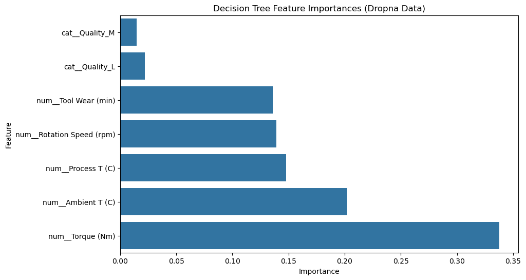

```
Model: Gradient Boosting
```

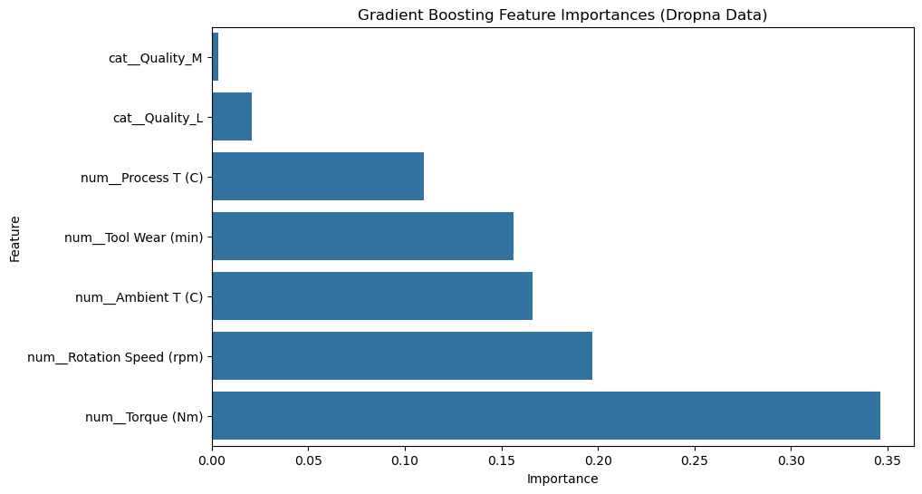

```
Model: AdaBoost
```

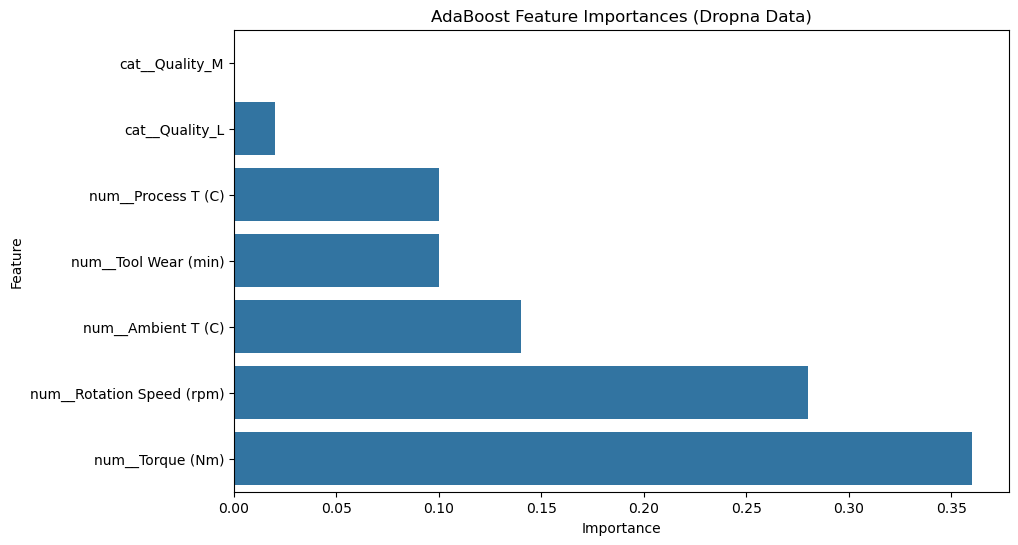

```
Model: Random Forest
```

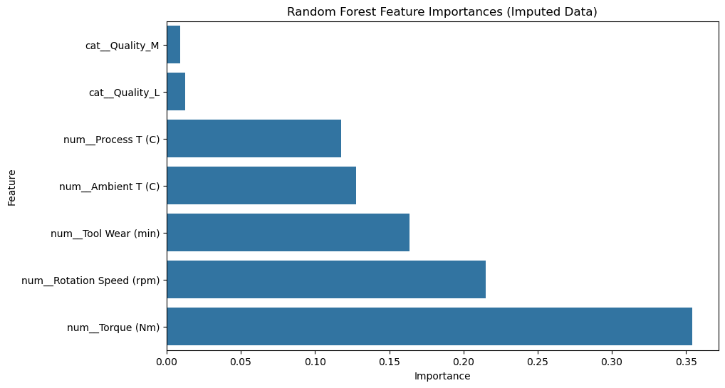

```
Model: Decision Tree
```

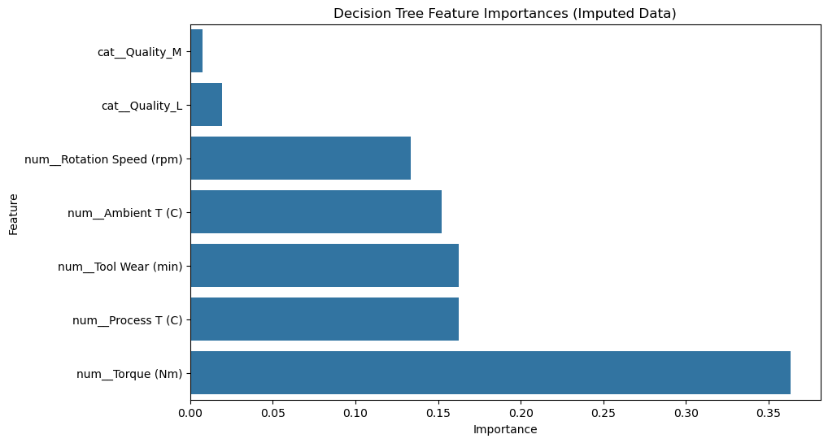

```
Model: Gradient Boosting
```

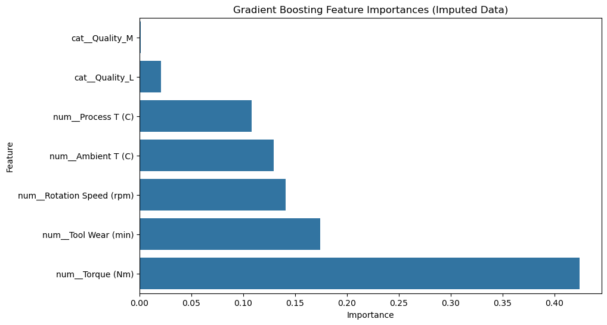

```
Model: AdaBoost
```

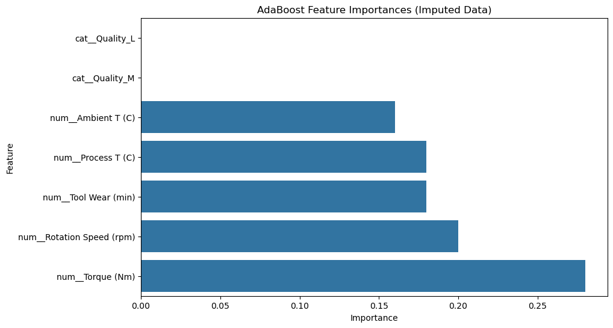

```python
warnings.filterwarnings("ignore", category=FutureWarning, message="The SAMME.R algorithm")

# Process models trained on dropna data
for model_name, pipeline in models_dropna.items():
    pipeline.fit(X_train_dropna, y_train_dropna)

    preprocessor = pipeline.named_steps['preprocessor']
    model_step_name = list(pipeline.named_steps.keys())[-1]
    model = pipeline.named_steps[model_step_name]

    if hasattr(model, 'feature_importances_'):
        print(f"Model: {model_name}")
        feature_importances = model.feature_importances_
        feature_names = preprocessor.get_feature_names_out()
        feature_importance_df = pd.DataFrame({
            'Feature': feature_names,
            'Importance': feature_importances
        }).sort_values(by='Importance', ascending=True)

        # Plot feature importances
        plt.figure(figsize=(10, 6))
        sns.barplot(x='Importance', y='Feature', data=feature_importance_df)
        plt.title(f'{model_name} Feature Importances (Dropna Data)')
        plt.show()

# Process models trained on imputed data
for model_name, pipeline in models_imputed.items():
    pipeline.fit(X_train_imputed, y_train_imputed)

    preprocessor = pipeline.named_steps['preprocessor']
    model_step_name = list(pipeline.named_steps.keys())[-1]
    model = pipeline.named_steps[model_step_name]

    if hasattr(model, 'feature_importances_'):
        print(f"Model: {model_name}")
        feature_importances = model.feature_importances_
        feature_names = preprocessor.get_feature_names_out()
        feature_importance_df = pd.DataFrame({
            'Feature': feature_names,
            'Importance': feature_importances
        }).sort_values(by='Importance', ascending=True)

        plt.figure(figsize=(10, 6))
        sns.barplot(x='Importance', y='Feature', data=feature_importance_df)
        plt.title(f'{model_name} Feature Importances (Imputed Data)')
        plt.show()
```

The bar graphs above show the feature importances for the models that support it (i.e. Only models with feature_importances_ would work) I will not be removing any features since they seem to be mostly somewhat important. I will also not be feature engineering new features since they already have quite high predictive power, and because this is an imbalanced date, featuring new features mighit cause it to be even more `biased` towards majority data.

# Phase 4: Training and Evaluating the improved Models

#### Using a for loop to train every model with their respective pipeline

Using a for loop, I run every model in the pipeline using GridSearchCV  
`GridSearchCV` is a tool that automates the tuning of hyperparameters for machine learning models. It reads the hyperparameters defined in param_grids[model_name], and stratified_kf defined earlier, to "fold" each hyperparameter combination and evaluate them using cross validation. GridSearchCV then fits the training data into the model with the best hyperparameter that produced the best performance.  
I then insert the best score and the best model into the results

```python
warnings.filterwarnings("ignore", category=FutureWarning, message="The SAMME.R algorithm")

# Training and evaluating models with Drop Missing Data approach
dropna_results = {}
for model_name, pipeline in models_dropna.items():
    grid = GridSearchCV(pipeline, param_grid=param_grids[model_name], cv=stratified_kf, scoring='roc_auc', verbose=3)
    grid.fit(X_train_dropna, y_train_dropna)
    dropna_results[model_name] = {
        'best_score': grid.best_score_,
        'best_estimator': grid.best_estimator_
    }

# Training and evaluating models with Impute Missing Data approach
imputed_results = {}
for model_name, pipeline in models_imputed.items():
    grid = GridSearchCV(pipeline, param_grid=param_grids[model_name], cv=stratified_kf, scoring='roc_auc', verbose=3)
    grid.fit(X_train_imputed, y_train_imputed)
    imputed_results[model_name] = {
        'best_score': grid.best_score_,
        'best_estimator': grid.best_estimator_
    }
```

[output not shown]

[output cut: 779 more lines]

[output not shown]

As seen from the output, I am outputting every model fit. This is done using the `verbose=(number)` method. Verbose outputs the folding process happening, which is a good visualization to show whether your program has froze or is just taking some time to run.

# Phase 5: Creating a baseline model for performance comparison

```
Classification Report for Imputed Data (Stratified):
              precision    recall  f1-score   support

           0       0.97      0.97      0.97      5797
           1       0.01      0.01      0.01       203

    accuracy                           0.93      6000
   macro avg       0.49      0.49      0.49      6000
weighted avg       0.93      0.93      0.93      6000


Classification Report for Dropna Data (Stratified):
              precision    recall  f1-score   support

           0       0.97      0.96      0.97      5081
           1       0.03      0.03      0.03       178

    accuracy                           0.93      5259
   macro avg       0.50      0.50      0.50      5259
weighted avg       0.93      0.93      0.93      5259


Model Evaluation Summary:
                                        Approach  Test Set Accuracy  \
Model
Dummy Baseline (Stratified)  Impute Missing Data           0.933333
Dummy Baseline (Stratified)    Drop Missing Data           0.932497

                             Test F1 Score
Model
Dummy Baseline (Stratified)       0.933174
Dummy Baseline (Stratified)       0.933299
```

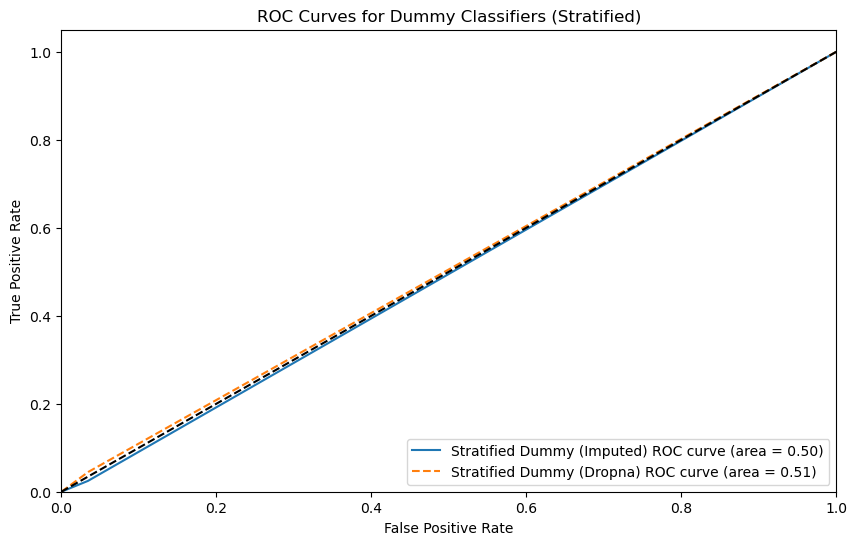

```python
dummyevaluation = []


dummy_pipeline_imputed = Pipeline([
    ('preprocessor', imputer_preprocessor),
    ('dummy', DummyClassifier(strategy='stratified'))
])


dummy_pipeline_imputed.fit(X_train_imputed, y_train_imputed)
y_pred_dummy_imputed = dummy_pipeline_imputed.predict(X_test_imputed)
y_pred_proba_dummy_imputed = dummy_pipeline_imputed.predict_proba(X_test_imputed)[:, 1]


dummy_test_accuracy_imputed = accuracy_score(y_test_imputed, y_pred_dummy_imputed)
dummy_f1_imputed = f1_score(y_test_imputed, y_pred_dummy_imputed, average='weighted', zero_division=1)


dummyevaluation.append({
    'Approach': 'Impute Missing Data',
    'Model': 'Dummy Baseline (Stratified)',
    'Test Set Accuracy': dummy_test_accuracy_imputed,
    'Test F1 Score': dummy_f1_imputed
})


print("Classification Report for Imputed Data (Stratified):")
print(classification_report(y_test_imputed, y_pred_dummy_imputed, zero_division=1))


dummy_pipeline_dropna = Pipeline([
    ('dummy', DummyClassifier(strategy='stratified'))
])


dummy_pipeline_dropna.fit(X_train_dropna, y_train_dropna)
y_pred_dummy_dropna = dummy_pipeline_dropna.predict(X_test_dropna)
y_pred_proba_dummy_dropna = dummy_pipeline_dropna.predict_proba(X_test_dropna)[:, 1]  # Probability for positive class


dummy_test_accuracy_dropna = accuracy_score(y_test_dropna, y_pred_dummy_dropna)
dummy_f1_dropna = f1_score(y_test_dropna, y_pred_dummy_dropna, average='weighted', zero_division=1)


dummyevaluation.append({
    'Approach': 'Drop Missing Data',
    'Model': 'Dummy Baseline (Stratified)',
    'Test Set Accuracy': dummy_test_accuracy_dropna,
    'Test F1 Score': dummy_f1_dropna
})


print("\nClassification Report for Dropna Data (Stratified):")
print(classification_report(y_test_dropna, y_pred_dummy_dropna, zero_division=1))


dummyevaluation_df = pd.DataFrame(dummyevaluation).set_index('Model')
print("\nModel Evaluation Summary:")
print(dummyevaluation_df)


fpr_imputed, tpr_imputed, _ = roc_curve(y_test_imputed, y_pred_proba_dummy_imputed)
roc_auc_imputed = auc(fpr_imputed, tpr_imputed)

fpr_dropna, tpr_dropna, _ = roc_curve(y_test_dropna, y_pred_proba_dummy_dropna)
roc_auc_dropna = auc(fpr_dropna, tpr_dropna)

plt.figure(figsize=(10, 6))
plt.plot(fpr_imputed, tpr_imputed, label=f'Stratified Dummy (Imputed) ROC curve (area = {roc_auc_imputed:.2f})')
plt.plot(fpr_dropna, tpr_dropna, linestyle='--', label=f'Stratified Dummy (Dropna) ROC curve (area = {roc_auc_dropna:.2f})')

# Plot the ROC settings
plt.plot([0, 1], [0, 1], 'k--')
plt.xlim([0.0, 1.0])
plt.ylim([0.0, 1.05])
plt.xlabel('False Positive Rate')
plt.ylabel('True Positive Rate')
plt.title('ROC Curves for Dummy Classifiers (Stratified)')
plt.legend(loc="lower right")
plt.show()
```

Even though from the results, we can see that the test set accuracy is very high, however the ROC curve show that the model is achieving that from pure guessing. This shows that this model is not reliable. As expected from an imbalanced dataset  
We will use this model as baseline to making a good model that can reliably predict data by learning patterns, rather than guessing (i.e. a higher ROC AUC score)

# Phase 6: Determine Model Performance

Creating a new array for the results to append into.

```python
evaluation_results = []
```

## Collating model performance for dropna() datas

```python
approach = 'Drop Missing Data'
results = dropna_results
X_test = X_test_dropna
y_test = y_test_dropna

for model_name, result in results.items():
    best_pipeline = result['best_estimator']

    y_pred = best_pipeline.predict(X_test)

    accuracy = accuracy_score(y_test, y_pred)
    train_F1 = f1_score(y_test, y_pred, average='weighted', zero_division=1)
    test_F1 = f1_score(y_test, y_pred, average='weighted', zero_division=1)

    evaluation_results.append({
        'Approach': approach,
        'Model': model_name,
        'Test Set Accuracy': accuracy,
        'Training F1 Score': train_F1,
        'Test F1 Score': test_F1
    })

warnings.filterwarnings("ignore", category=FutureWarning)
```

## Collating model performance data for SimpleImputer() datas

```python
approach = 'Impute Missing Data'
results = imputed_results
X_test = X_test_imputed
y_test = y_test_imputed

for model_name, result in results.items():
    best_pipeline = result['best_estimator']

    y_pred = best_pipeline.predict(X_test)

    accuracy = accuracy_score(y_test, y_pred)
    train_F1 = f1_score(y_test, y_pred, average='weighted', zero_division=1)
    test_F1 = f1_score(y_test, y_pred, average='weighted', zero_division=1)

    evaluation_results.append({
        'Approach': approach,
        'Model': model_name,
        'Test Set Accuracy': accuracy,
        'Training F1 Score': train_F1,
        'Test F1 Score': test_F1
    })

warnings.filterwarnings("ignore", category=FutureWarning)
```

## Display the evaluation results

```python
evaluation_df = pd.DataFrame(evaluation_results)
evaluation_df.set_index('Model', inplace=True)

evaluation_df
```

| Model | Approach | Test Set Accuracy | Training F1 Score | Test F1 Score |
| --- | --- | --- | --- | --- |
| Logistic Regression | Drop Missing Data | 0.804906 | 0.866033 | 0.866033 |
| SVC | Drop Missing Data | 0.813843 | 0.871769 | 0.871769 |
| Random Forest | Drop Missing Data | 0.966724 | 0.971298 | 0.971298 |
| KNN | Drop Missing Data | 0.977372 | 0.973809 | 0.973809 |
| Decision Tree | Drop Missing Data | 0.927363 | 0.943983 | 0.943983 |
| Gradient Boosting | Drop Missing Data | 0.989352 | 0.988699 | 0.988699 |
| AdaBoost | Drop Missing Data | 0.968245 | 0.954472 | 0.954472 |
| Logistic Regression | Impute Missing Data | 0.811000 | 0.869851 | 0.869851 |
| SVC | Impute Missing Data | 0.826500 | 0.879704 | 0.879704 |
| Random Forest | Impute Missing Data | 0.966167 | 0.970850 | 0.970850 |
| KNN | Impute Missing Data | 0.975833 | 0.971727 | 0.971727 |
| Decision Tree | Impute Missing Data | 0.910667 | 0.933340 | 0.933340 |
| Gradient Boosting | Impute Missing Data | 0.987167 | 0.986108 | 0.986108 |
| AdaBoost | Impute Missing Data | 0.968500 | 0.955035 | 0.955035 |

### Plotting the comparison results

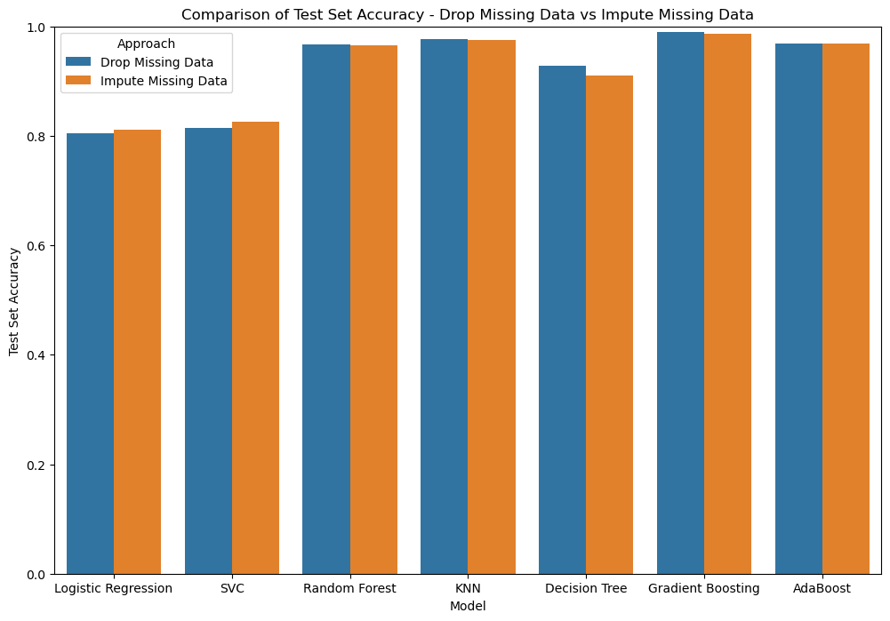

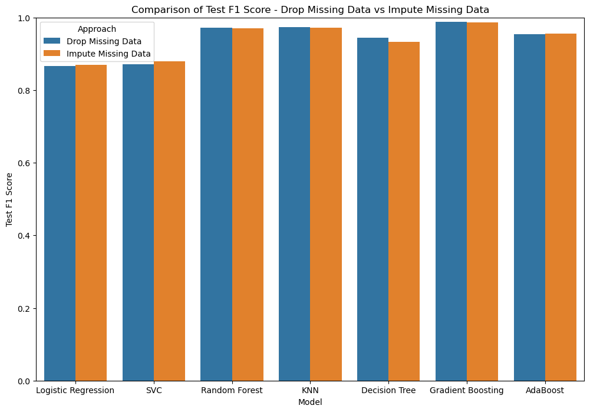

```python
# Plotting the comparison results
plt.figure(figsize=(12, 8))
sns.barplot(x=evaluation_df.index, y='Test Set Accuracy', hue='Approach', data=evaluation_df)
plt.title('Comparison of Test Set Accuracy - Drop Missing Data vs Impute Missing Data')
plt.ylim(0, 1)
plt.show()

plt.figure(figsize=(12, 8))
sns.barplot(x=evaluation_df.index, y='Test F1 Score', hue='Approach', data=evaluation_df)
plt.title('Comparison of Test F1 Score - Drop Missing Data vs Impute Missing Data')
plt.ylim(0, 1)
plt.show()
```

### Classification report and confusion matrix for each model to evaluate class-based performance

```
----- Evaluation for Drop Missing Data -----

Classification Report for Logistic Regression (Drop Missing Data):
              precision    recall  f1-score   support

     Class 0       0.99      0.80      0.89      5081
     Class 1       0.13      0.87      0.23       178

    accuracy                           0.80      5259
   macro avg       0.56      0.83      0.56      5259
weighted avg       0.97      0.80      0.87      5259
```

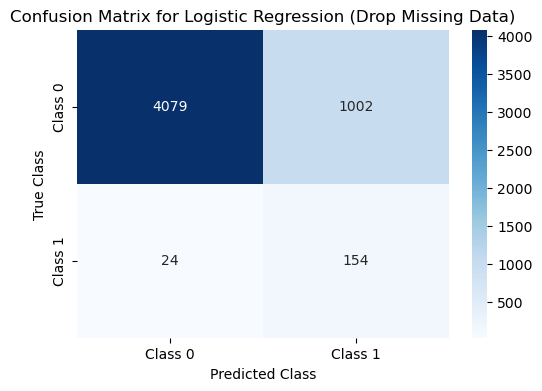

```
Classification Report for SVC (Drop Missing Data):
              precision    recall  f1-score   support

     Class 0       0.99      0.81      0.89      5081
     Class 1       0.14      0.86      0.24       178

    accuracy                           0.81      5259
   macro avg       0.57      0.84      0.57      5259
weighted avg       0.97      0.81      0.87      5259
```

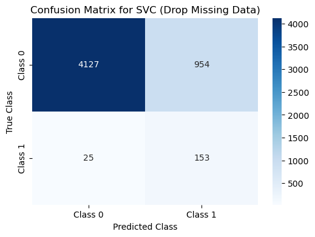

```
Classification Report for Random Forest (Drop Missing Data):
              precision    recall  f1-score   support

     Class 0       1.00      0.97      0.98      5081
     Class 1       0.50      0.92      0.65       178

    accuracy                           0.97      5259
   macro avg       0.75      0.94      0.82      5259
weighted avg       0.98      0.97      0.97      5259
```

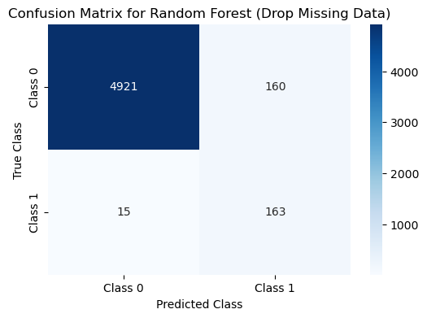

```
Classification Report for KNN (Drop Missing Data):
              precision    recall  f1-score   support

     Class 0       0.98      1.00      0.99      5081
     Class 1       0.82      0.42      0.56       178

    accuracy                           0.98      5259
   macro avg       0.90      0.71      0.77      5259
weighted avg       0.97      0.98      0.97      5259
```

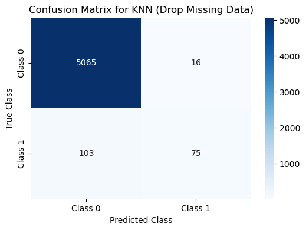

```
Classification Report for Decision Tree (Drop Missing Data):
              precision    recall  f1-score   support

     Class 0       1.00      0.93      0.96      5081
     Class 1       0.31      0.90      0.46       178

    accuracy                           0.93      5259
   macro avg       0.65      0.91      0.71      5259
weighted avg       0.97      0.93      0.94      5259
```

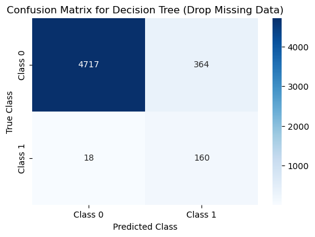

```
Classification Report for Gradient Boosting (Drop Missing Data):
              precision    recall  f1-score   support

     Class 0       0.99      1.00      0.99      5081
     Class 1       0.94      0.73      0.82       178

    accuracy                           0.99      5259
   macro avg       0.97      0.86      0.91      5259
weighted avg       0.99      0.99      0.99      5259
```

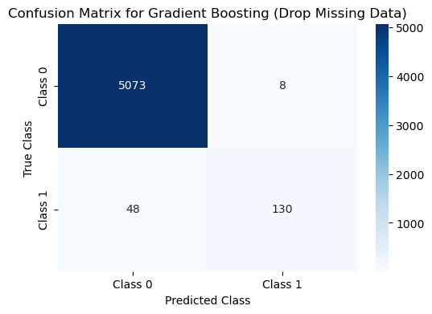

```
Classification Report for AdaBoost (Drop Missing Data):
              precision    recall  f1-score   support

     Class 0       0.97      1.00      0.98      5081
     Class 1       1.00      0.06      0.12       178

    accuracy                           0.97      5259
   macro avg       0.98      0.53      0.55      5259
weighted avg       0.97      0.97      0.95      5259
```

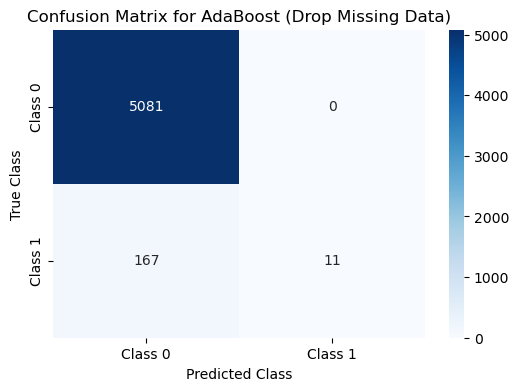

```
----- Evaluation for Impute Missing Data -----

Classification Report for Logistic Regression (Impute Missing Data):
              precision    recall  f1-score   support

     Class 0       0.99      0.81      0.89      5797
     Class 1       0.13      0.83      0.23       203

    accuracy                           0.81      6000
   macro avg       0.56      0.82      0.56      6000
weighted avg       0.96      0.81      0.87      6000
```

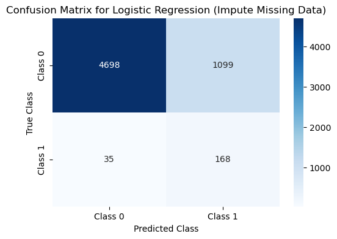

```
Classification Report for SVC (Impute Missing Data):
              precision    recall  f1-score   support

     Class 0       0.99      0.83      0.90      5797
     Class 1       0.14      0.82      0.24       203

    accuracy                           0.83      6000
   macro avg       0.57      0.82      0.57      6000
weighted avg       0.96      0.83      0.88      6000
```

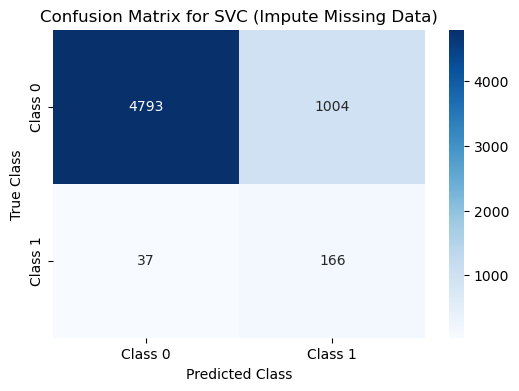

```
Classification Report for Random Forest (Impute Missing Data):
              precision    recall  f1-score   support

     Class 0       1.00      0.97      0.98      5797
     Class 1       0.50      0.91      0.65       203

    accuracy                           0.97      6000
   macro avg       0.75      0.94      0.81      6000
weighted avg       0.98      0.97      0.97      6000
```

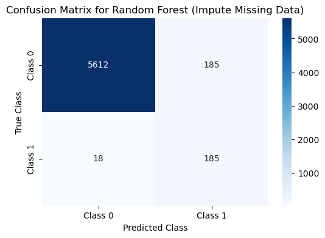

```
Classification Report for KNN (Impute Missing Data):
              precision    recall  f1-score   support

     Class 0       0.98      1.00      0.99      5797
     Class 1       0.80      0.38      0.52       203

    accuracy                           0.98      6000
   macro avg       0.89      0.69      0.75      6000
weighted avg       0.97      0.98      0.97      6000
```

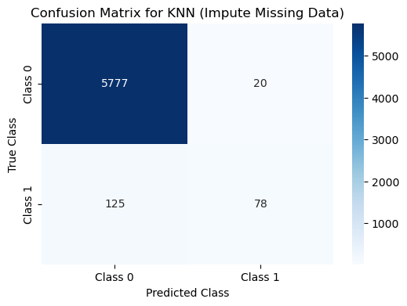

```
Classification Report for Decision Tree (Impute Missing Data):
              precision    recall  f1-score   support

     Class 0       1.00      0.91      0.95      5797
     Class 1       0.26      0.92      0.41       203

    accuracy                           0.91      6000
   macro avg       0.63      0.91      0.68      6000
weighted avg       0.97      0.91      0.93      6000
```

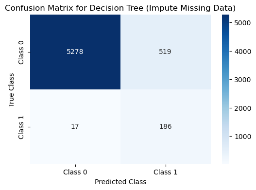

```
Classification Report for Gradient Boosting (Impute Missing Data):
              precision    recall  f1-score   support

     Class 0       0.99      1.00      0.99      5797
     Class 1       0.94      0.67      0.78       203

    accuracy                           0.99      6000
   macro avg       0.96      0.83      0.89      6000
weighted avg       0.99      0.99      0.99      6000
```

[2 more figures not shown]

```python
datasets = {
    "Drop Missing Data": {"X_test": X_test_dropna, "y_test": y_test_dropna, "results": dropna_results},
    "Impute Missing Data": {"X_test": X_test_imputed, "y_test": y_test_imputed, "results": imputed_results},
}


for approach, data in datasets.items():
    X_test = data["X_test"]
    y_test = data["y_test"]
    results = data["results"]

    print(f"\n======= Evaluation for {approach} =======")

    for model_name, result in results.items():

        best_pipeline = result['best_estimator']
        y_pred = best_pipeline.predict(X_test)


        print(f"\nClassification Report for {model_name} ({approach}):")
        print(classification_report(y_test, y_pred, target_names=["Class 0", "Class 1"]))


        conf_matrix = confusion_matrix(y_test, y_pred)
        plt.figure(figsize=(6, 4))
        sns.heatmap(conf_matrix, annot=True, fmt='d', cmap='Blues', xticklabels=["Class 0", "Class 1"], yticklabels=["Class 0", "Class 1"])
        plt.title(f"Confusion Matrix for {model_name} ({approach})")
        plt.xlabel("Predicted Class")
        plt.ylabel("True Class")
        plt.show()
```

From this, we can see clearly the performance of the models for predicting EACH class `0` and `1`.

We want to look for models who have F1 Scores near `1.00` for both Class 0 and Class 1. Which seems to be `Gradient Boosting`

### Comparing the results of dropping or imputing missing data

```python
dropna_accuracies = [result['Test Set Accuracy'] for result in evaluation_results if result['Approach'] == 'Drop Missing Data']
impute_accuracies = [result['Test Set Accuracy'] for result in evaluation_results if result['Approach'] == 'Impute Missing Data']

mean_accuracy_dropna = np.mean(dropna_accuracies)
mean_accuracy_impute = np.mean(impute_accuracies)

print(f"Average Test Set Accuracy with Drop Missing Data: {mean_accuracy_dropna:.4f}")
print(f"Average Test Set Accuracy with Impute Missing Data: {mean_accuracy_impute:.4f}")

if mean_accuracy_dropna > mean_accuracy_impute:
    print("\nConclusion: Dropping missing data resulted in higher overall accuracy.")
elif mean_accuracy_dropna < mean_accuracy_impute:
    print("\nConclusion: Imputing missing data resulted in higher overall accuracy.")
else:
    print("\nConclusion: Both approaches resulted in the same overall accuracy.")
```

```
Average Test Set Accuracy with Drop Missing Data: 0.9211
Average Test Set Accuracy with Impute Missing Data: 0.9208

Conclusion: Dropping missing data resulted in higher overall accuracy.
```

From this checker, we can see that even though one type of data has higher accuracy than the other, the difference is minimal.  
My explanation for this is because imputing data is essentially filling up missing datas with fake data that they guessed from using the other datas, while this can be useful for smaller datas as it can keep our data size for better predictions, for larger datas, we can afford the luxury of dropping the missing datas to leave out the most truthful and realistic datas.

Hence, in conclusion, dropna data and imputed data has minimal difference in THIS dataset.

# Phase 7: Reliability Check

## Checking for overfitting with ROC curve

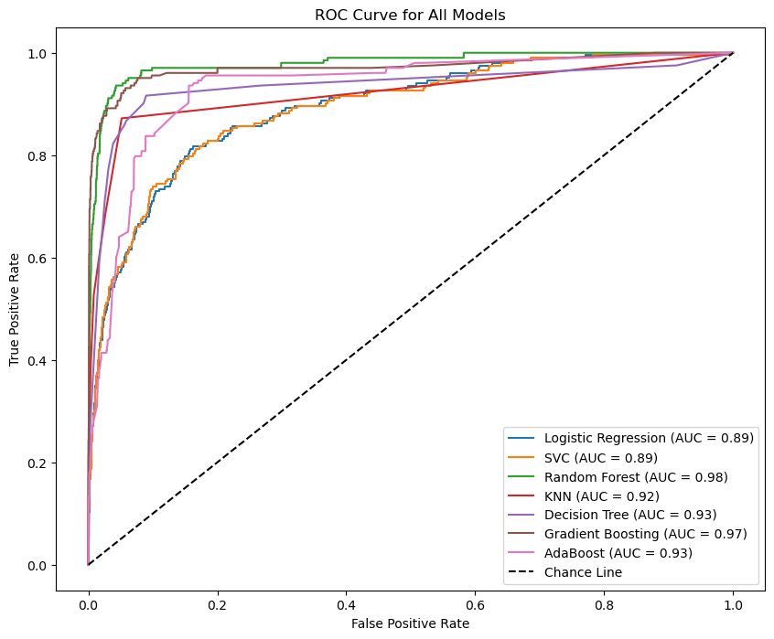

```python
plt.figure(figsize=(10, 8))
for model_name, result in results.items():
    best_pipeline = result['best_estimator']
    if hasattr(best_pipeline, 'predict_proba'):
        y_prob = best_pipeline.predict_proba(X_test)[:, 1]
        fpr, tpr, thresholds = roc_curve(y_test, y_prob)
        roc_auc = auc(fpr, tpr)

        plt.plot(fpr, tpr, label=f'{model_name} (AUC = {roc_auc:.2f})')

plt.plot([0, 1], [0, 1], 'k--', label='Chance Line')
plt.xlabel('False Positive Rate')
plt.ylabel('True Positive Rate')
plt.title('ROC Curve for All Models')
plt.legend(loc='lower right')
plt.show()
```

## Checking for overfitting by comparing Train Data Accuracy with Test Data Accuracy

This will compare the train scores with the test scores, if there is a 0.1 difference and above, it might be overfitting or underfitting, if it doesn't, it's well-fitted model.

```
--- Logistic Regression ---
Training Set Accuracy: 0.8111
Test Set Accuracy: 0.8110
Training F1 Score: 0.8698
Test F1 Score: 0.8699
Result: This model is well-fitted.

--- SVC ---
Training Set Accuracy: 0.8274
Test Set Accuracy: 0.8265
Training F1 Score: 0.8801
Test F1 Score: 0.8797
Result: This model is well-fitted.

--- Random Forest ---
Training Set Accuracy: 0.9737
Test Set Accuracy: 0.9662
Training F1 Score: 0.9771
Test F1 Score: 0.9708
Result: This model is well-fitted.

--- KNN ---
Training Set Accuracy: 0.9809
Test Set Accuracy: 0.9758
Training F1 Score: 0.9779
Test F1 Score: 0.9717
Result: This model is well-fitted.

--- Decision Tree ---
Training Set Accuracy: 0.9191
Test Set Accuracy: 0.9107
Training F1 Score: 0.9392
Test F1 Score: 0.9333
Result: This model is well-fitted.

--- Gradient Boosting ---
Training Set Accuracy: 0.9925
Test Set Accuracy: 0.9872
Training F1 Score: 0.9921
Test F1 Score: 0.9861
```

[output cut: 15 more lines]

```
Random Forest                     0.973714           0.966167
KNN                               0.980857           0.975833
Decision Tree                     0.919143           0.910667
Gradient Boosting                 0.992500           0.987167
AdaBoost                          0.967429           0.968500

                     Training F1 Score  Test F1 Score
Model
Logistic Regression           0.869779       0.869851
SVC                           0.880096       0.879704
Random Forest                 0.977094       0.970850
KNN                           0.977949       0.971727
Decision Tree                 0.939182       0.933340
Gradient Boosting             0.992077       0.986108
AdaBoost                      0.952666       0.955035
```

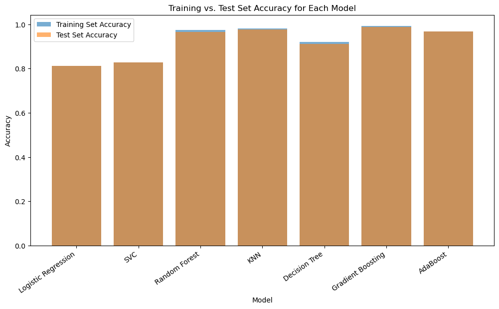

```python
overfitting_results = []

for model_name, result in results.items():
    best_pipeline = result['best_estimator']

    y_train_pred = best_pipeline.predict(X_train_imputed)
    y_test_pred = best_pipeline.predict(X_test_imputed)

    train_accuracy = accuracy_score(y_train_imputed, y_train_pred)
    test_accuracy = accuracy_score(y_test_imputed, y_test_pred)

    train_F1 = f1_score(y_train_imputed, y_train_pred, average='weighted', zero_division=1)
    test_F1 = f1_score(y_test_imputed, y_test_pred, average='weighted', zero_division=1)

    overfitting_results.append({
        'Model': model_name,
        'Training Set Accuracy': train_accuracy,
        'Test Set Accuracy': test_accuracy,
        'Training F1 Score': train_F1,
        'Test F1 Score': test_F1
    })

    print(f'--- {model_name} ---')
    print(f'Training Set Accuracy: {train_accuracy:.4f}')
    print(f'Test Set Accuracy: {test_accuracy:.4f}')
    print(f'Training F1 Score: {train_F1:.4f}')
    print(f'Test F1 Score: {test_F1:.4f}')

    if train_accuracy > test_accuracy + 0.1:
        print("Result: This model is likely overfitting.")
    elif abs(train_accuracy - test_accuracy) <= 0.1:
        print("Result: This model is well-fitted.")
    else:
        print("Result: This model might be underfitting.")
    print()

overfitting_df = pd.DataFrame(overfitting_results).set_index('Model')
print("\nOverfitting Test Summary:")
print(overfitting_df)

# Visualize the training vs. test set performance
plt.figure(figsize=(12, 6))
plt.bar(overfitting_df.index, overfitting_df['Training Set Accuracy'], label='Training Set Accuracy', alpha=0.6)
plt.bar(overfitting_df.index, overfitting_df['Test Set Accuracy'], label='Test Set Accuracy', alpha=0.6)
plt.title('Training vs. Test Set Accuracy for Each Model')
plt.xlabel('Model')
plt.ylabel('Accuracy')
plt.legend()
plt.xticks(rotation=35, ha="right")
plt.show()
```

Here, we compare the accuracy of `Training Results` with the `Test Results`. If overfitting is happening, there would be significant differences between them, hence I will set a maximum difference of `0.1` for it to be considered well-fitted.

From the results, we can see that all the models are well-fitted. Indicating no overfitting or underfitting, telling us that the models are reliable.